```python
%%javascript
IPython.OutputArea.prototype._should_scroll = function(lines) {
    return false;
}
```

```python
# to load images for this tutorial
from IPython.display import Image
import os
path = os.getcwd()
```

# Post Overview.

1. Provide an Introduction to \(\chi^{2} \) Test for Association.
2. Discuss the Assumptions for the \(\chi^{2} \) Test for Association.
3. \(\chi^{2} \) Test for Association Formulas.
4. Demonstrate how perform a \(\chi^{2} \) Test for Association using SPSS.
5. Infographic Overview on \(\chi^{2} \) Test for Association.

# Introduction to \(\chi^{2} \) Test for Association.

**\(\chi^{2} \) Test for Association:**

- **Test Statistic Selection:** In this example we will use the \(\chi^{2} \) Test for Association.
- **Test Statistic Selection Rationale:** The Chi-square tests for association between two nominal (categorical) variables, to determine if they are statistically independent. In other words, this test allows us to determine if the our variables conversion, and landing page version, are statistically independent.

**Assumptions for using Chi-Square Test for Association**

- Three assumptions must be met to conduct a chi-square test for association:
  1. You have categorical variables that are either nominal or ordinal. In our example we have nominal and binary categories (converted or not converted). Ordinal just refers to categorical data that has order (cold, warm, hot).
  2. You have independence of observations. This means that there is no relationship between the observations in the group and between the categories in the group. In other words, you need to have different participants in each group. We do not have a user that visited both landing pages. They were either directed to version A or version B.
  3. All cells should have expected counts greater than five.

**Hypothetical \(\chi^{2} \) Example:**

- **Example:** Exercise and Heart Disease.
  - **Tested association:** Determine if there is an association between exercise and the presence of heart disease.
  - **Data types:** Both variables are categorical (aka nominal) and binomial.
  - **Variable 1 (exercise):** yes or no (binomial)
  - **Variable 2 (presence of heart disease):** yes or no (binomial)
  - **Data aggregated values:** Counts
  - **Data presentation:** typically a frequency table that aggregates (counts) the number of individuals that fall in each bucket or cell.

**Understanding Chi-Square Test for Association Assumptions**

- Chi-square test for association between two nominal variables by by comparing the observed frequencies to the frequencies we would expect if there was no association between the two nominal variables.
- This means we would have our data frequency table, and we would then determine calculate an estimator from our pooled observations, and calculate an expected frequency table. This process will be demonstrated in the next section of this post.
- The expected frequencies are predicated on there being no association.
- The greater the association between the two categories, the greater the observed frequencies will differ from the expected frequencies.
- The less the two categories are associated, the closer the observed frequencies will be to the expected frequencies.
- Chi-square test produces a statistic based on the overall "amount" of difference between the expected and observed frequencies and is described as: \[\chi_{2} = \Sigma\frac{(\mathit{f}_{observed} - \mathit{f}_{expected})^{2}}{\mathit{f}_{expected}} \]  
  \(\mathit{f}_{observed} \) is the observed frequency from the observed counts in the cells  
  \(\mathit{f}_{expected} \) is the expected frequency if NO relationship existed between the two categories (converted not converted).
- The larger the difference between the observed frequencies to the expected frequencies, will result in a larger test statistic.
- The larger the test statistic, the greater the association and the more likely a statistically significant result.

# Discuss the Assumptions for the \(\chi^{2} \) Test for Association

**Chi-Square Test for Association Assumptions**

- Three assumptions must be met to conduct a chi-square test for association:
  1. You have categorical variables that are either nominal or ordinal. In our example we have nominal and binary categories (converted or not converted). Ordinal just refers to categorical data that has order (cold, warm, hot).
  2. You have independence of observations. This means that there is no relationship between the observations in the group and between the categories in the group. In other words, you need to have different participants in each group. We do not have a user that visited both landing pages. They were either directed to version A or version B.
  3. All cells should have expected counts greater than five.

# \(\chi^{2} \) Test for Association Formulas.

**Understanding Chi-Square Test for Association Assumptions**

- Chi-square test produces a statistic based on the overall "amount" of difference between the expected and observed frequencies and is described as: \[\chi_{2} = \Sigma\frac{(\mathit{f}_{observed} - \mathit{f}_{expected})^{2}}{\mathit{f}_{expected}} \]  
  \(\mathit{f}_{observed} \) is the observed frequency from the observed counts in the cells  
  \(\mathit{f}_{expected} \) is the expected frequency if NO relationship existed between the two categories (converted not converted).
- The larger the difference between the observed frequencies to the expected frequencies, will result in a larger test statistic.
- The larger the test statistic, the greater the association and the more likely a statistically significant result.

# Demonstrate how perform a \(\chi^{2} \) Test for Association using SPSS.

#### Steps

1. Case Study.
2. Set up your data.
3. Confirm data does not violate assumptions.
4. Weigh cases.
5. Carry out \(\chi^{2} \) Test for Association Procedure..
6. Interpret Results.
7. Infographic Overview on \(\chi^{2} \) Test for Association.

### Case Study

- A data scientist at an online retail company is tasked to design an split test determine if a new version of the company landing page would increase conversion rate, specifically a customer purchase.
- The company launched the online campaign for up to 7 days or until they have gathered 25,000 visits for each landing page version.
- Visitors were randomly assigned to either landing page version.
- The Null hypothesis \(H_{0} \): the customer conversion (number of purchases made by customers) is the same for both landing page versions. *There is no association between landing page version and conversion*.
- The Alternative hypothesis \(H_{A}\) (1-sided upper-tailed): the customer conversion (number of purchases made by customers) is higher in version B. *There is an association between the landing page version and conversion*.
- The level of significance \(\alpha = 0.05\).

### Step 1: Set up data

**SPSS Variable View**

- Either import or manually input data for the two variables of interest.
- In this example we want to determine if there is an association between the website landing page version and customer conversion.
- The web landing page is binary and nominal data. 1 = Version a, 2 = Version B.
- The frequency column (or row in the variable view) is the number of counts for each cell combination.

**SPSS Data View**

- The data view is aggregated data, and contains total count (frequencies).
- The other option would be to have it as individual scores for each participant, which would be "long" data view.
- Since we have the total frequency counts, we see that there are 25,000 instances per web landing version.

[figure not shown]

```python
# Variable view
img = os.path.join(path, 'static/images/chisquare_association/spss1.png')
Image(filename=img,  width = 800)
```

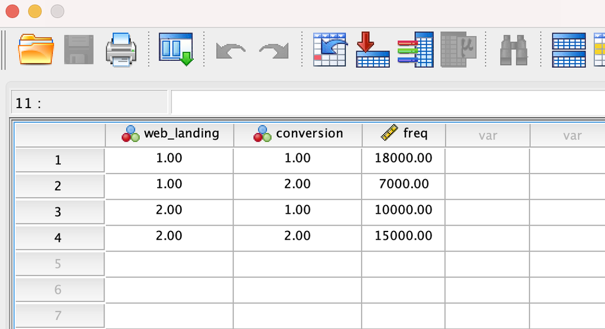

```python
# Data view
img = os.path.join(path, 'static/images/chisquare_association/spss2.png')
Image(filename=img,  width = 400)
```

### Step 2: Confirm data does not violate assumptions

**Why confirm assumptions?**

- A critical part of the process is confirming that the data we want to analyze meets the requirements for this model.
- Chi square test for associations have three requirements that must be met.
- If the data does not meet the models requirements, then it will provide misleading and inaccurate results.

**Assumptions for test statistic**

1. The data has two variables that are measured at the categorical level. \(\checkmark \)
   - The variables are web page landing version and conversion.
   - Web page landing version is either A or B. This is nominal/categorical data.
   - The "conversion" variable is either yes or no. This is nominal/categorical data.
   - The two variables are categorical, and meets the first assumption for two categorical variables.
2. The study has independence of observation. \(\checkmark \)
   - Each participant is only counted as one observation.
   - The participant was directed to either landing page A or B.
   - The participant either converted or did not convert.
   - The data meets the second assumption for independence of observation.
3. All cells should have expected counts greater than five. \(\checkmark \)
   - The data view confirms that the frequency is greater than 5.
   - The data meets the third assumption for greater than five instances per cell.

### Step 3: Weigh cases.

**Why weight cases?**

- SPSS assumes we are using individual scores, and not total counts.
- Since we are using total counts, we need to weight our cases before we can carry out the chi-square test for association.
- This data meets the assumptions.

**Procedure**

1. `Tool bar menu: Data → Weight Cases`
2. `Weight cases dialogue box: Select "Weight cases by" radial dial`
3. `Weight cases dialogue box: move frequency variable to "Frequency Variable" box.`
4. `Click "OK" button`
5. `DONE`

Note: weight cases procedure does result in visible changes in the data view window. Instead, you can confirm changes in the Output window, where you will see `WEIGHT BY freq`. Now we are ready to proceed with the Chi Square test. Keep in mind that if you plan to carry out other analysis, you will need to remove the weighting. Methods not described here.

[figure not shown]

```python
# Output window confirming data has been weighted
img = os.path.join(path, 'static/images/chisquare_association/spss3.png')
Image(filename=img, width=500)
```

### Step 4: Carry out \(\chi^{2} \) Test for Association Procedure.

This method will also generate the tests for the strength/magnitude of any association, and also checks for the assumption (#3) that the data has the expected counts greater than five.

**Procedure**

1. `Tool bar menu: Analyze → Descriptive Statistics → Crosstabs`
2. `Crosstabs dialogue box: Transfer web page landing variable to Row(s) box.`
3. `Crosstabs dialogue box: Transfer conversion variable to Column(s) box.`
4. `Crosstabs dialogue box: check "Display clustered bar charts".`
5. `Click Statistics button`
6. `Crosstabs: Statistics dialogue box: Select Chi-Square`
7. `Crosstabs: Statistics dialogue box → Nominal Area: Select Phi and Cramer's V`
8. `Crosstabs: Statistics dialogue box click on "Continue" button.`
9. `Crosstabs dialogue box: click Cells button`
10. `Crosstabs: Cell Display dialogue box: click Expected in Counts area`
11. `Crosstabs: Cell Display dialogue box → Percentages Area: check Row, Column and Total`
12. `Click Continue button`
13. `Crosstabs dialogue box: click OK button to generate output.`

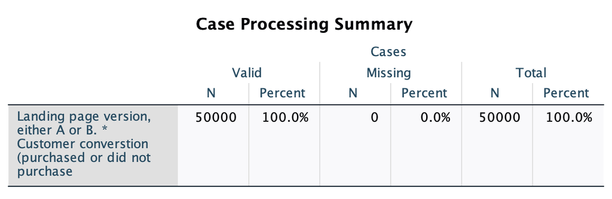

```python
img = os.path.join(path, 'static/images/chisquare_association/spss4.png')
Image(filename=img, width=600)
```

**Case Processing Summary: Table highlights how many valid and missing cases there are.**

- The row header highlights the cross tabulation of the two variables.
- All cases were valid ("50,000) and there were no missing values.

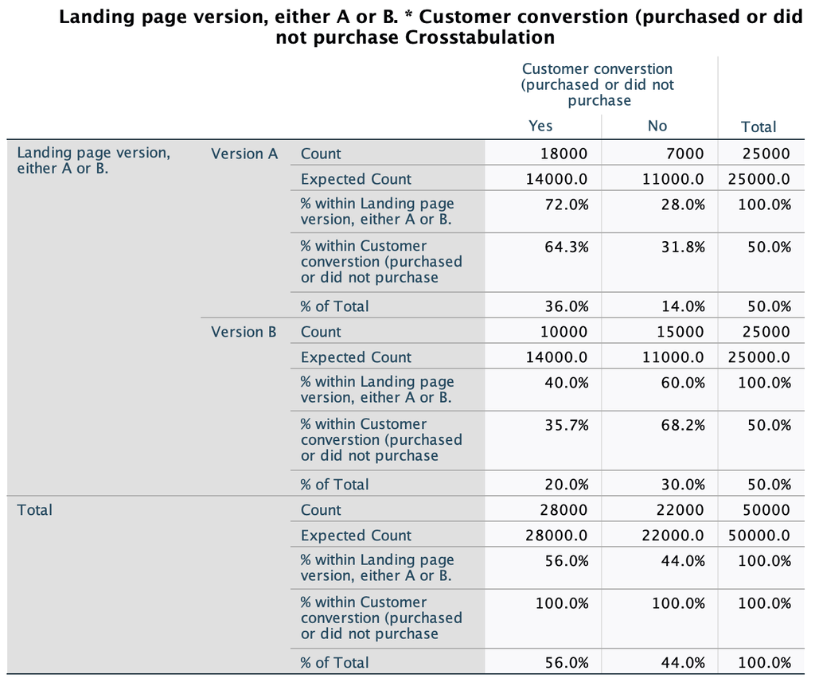

```python
img = os.path.join(path, 'static/images/chisquare_association/spss5.png')
Image(filename=img, width=600)
```

**Crosstabulation Table: Contains the observed and expected frequencies for each cell of the design.**

- Contains the observed and expected results by conditions.
- The model expected less conversions for Version A.
- The model expected more conversions for Version B.
- The next section will evaluate the Chi-square test for association table.

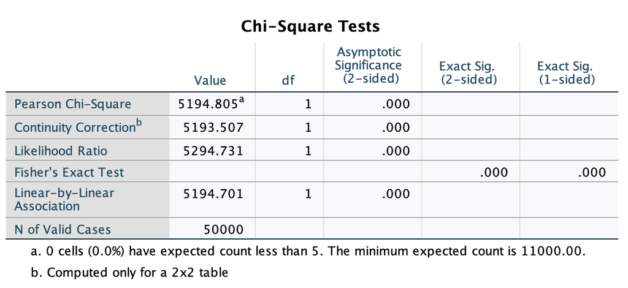

```python
img = os.path.join(path, 'static/images/chisquare_association/spss6.png')
Image(filename=img, width=600)
```

**Chi-Square tests for association.**

- This table contains various statistical tests, which includes the Chi-Square test.
- When you have a 2x2 crosstabuluation, such as in our example where we have two dichotomous variables, you can use either the Pearson's Chi-Squre or the Fisher's Exact Test.
- If one or both of the variables has more than two categories, you cannot use the Fisher's Exact test.
- The output also confirms that no cells have expected counts less than 5.
- To determine whether the chi-square test for association is statistically significant, consult the cell in the "Asymp. Sig. (2-sided)" column.
- If the p-value is > \(\alpha = 0.05 \), then the results are not statistical significant. Therefore, we would accept the Null Hypothesis \(H_{0}\).
- If the p-value is < \(\alpha = 0.05 \), then the results are statistical significant. Therefore, we would reject the Null Hypothesis \(H_{0}\) in favor to the Alternative Hypothesis \(H_{A}\).

### Step 5: Interpret Results.

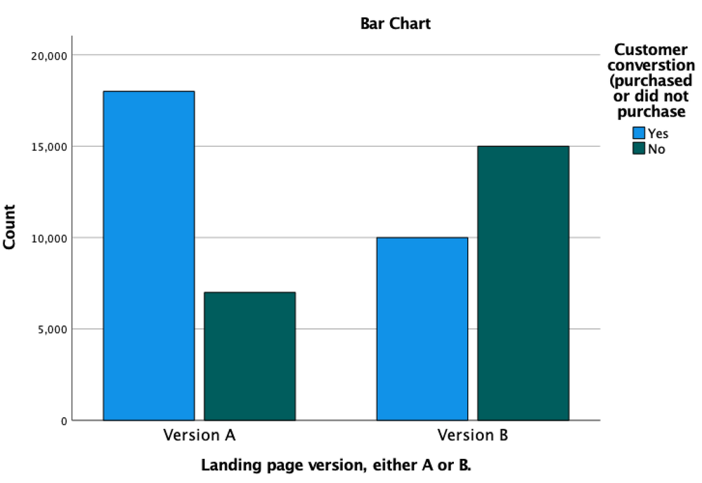

```python
img = os.path.join(path, 'static/images/chisquare_association/spss7.png')
Image(filename=img, width=600)
```

# Infographic Overview on \(\chi^{2} \) Test for Association.

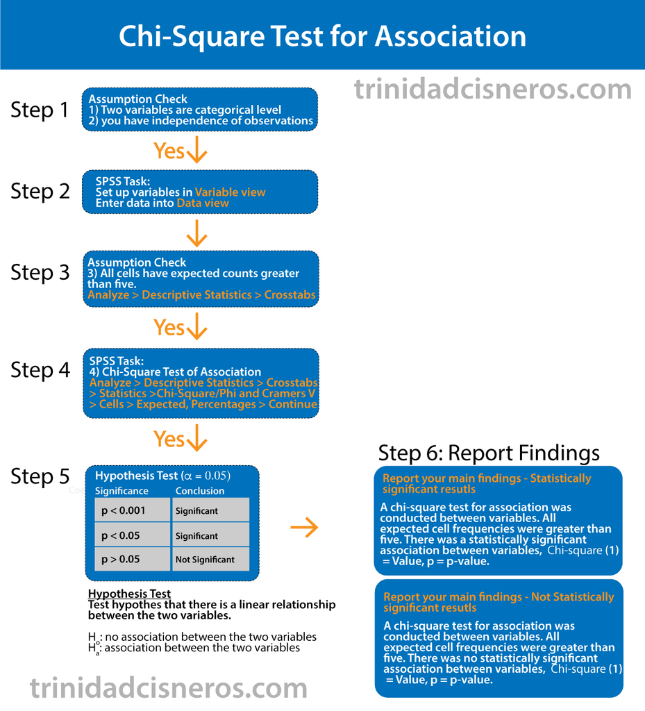

```python
img = os.path.join(path, 'static/images/chisquare_association/spss8.png')
Image(filename=img, width=700)
```